# 11_introduction_to_inference_py slides

```python
# run before presenting to create population
import pandas as pd
import numpy as np
virtual_ugrads = pd.DataFrame({'student_id': range(1,50001),'phone_type' : np.random.binomial(1,.63,50000) })

virtual_ugrads["phone_type"]= virtual_ugrads["phone_type"].apply(lambda x:"iphone" if x>0.5 else "other")
virtual_ugrads
```

|  | student_id | phone_type |
| --- | --- | --- |
| 0 | 1 | iphone |
| 1 | 2 | iphone |
| 2 | 3 | other |
| 3 | 4 | other |
| 4 | 5 | iphone |
| ... | ... | ... |
| 49995 | 49996 | iphone |
| 49996 | 49997 | other |
| 49997 | 49998 | iphone |
| 49998 | 49999 | other |
| 49999 | 50000 | iphone |

50000 rows × 2 columns

## DSCI 100 - Introduction to Data Science

### Lecture 11 - Introduction to inference & sampling

[figure not shown]

Source: [Desirée De Lyon's Tea cup Giraffe's statistics course](https://tinystats.github.io/teacups-giraffes-and-statistics/02_bellCurve.html)

## What is statistical inference?

Statistical inference is the process of using a *sample* to make conclusions about a wider *population* the sample came from.

**Why?:** It's often expensive or not possible to measure the whole population.

#### E.g.: we want to know the average width of a species of sea star

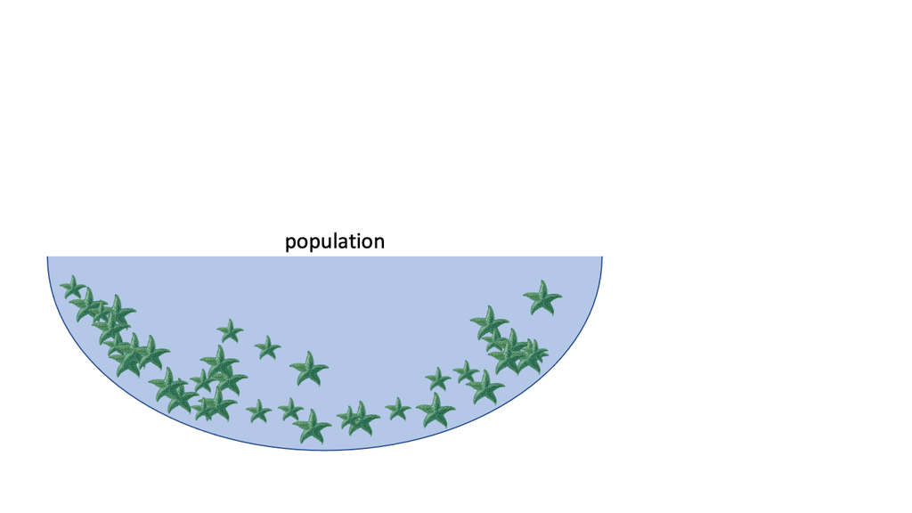

## What is statistical inference?

Statistical inference is the process of using a *sample* to make conclusions about a wider *population* the sample came from.

**Why?:** It's often expensive or not possible to measure the whole population.

#### E.g.: we want to know the average width of a species of sea star

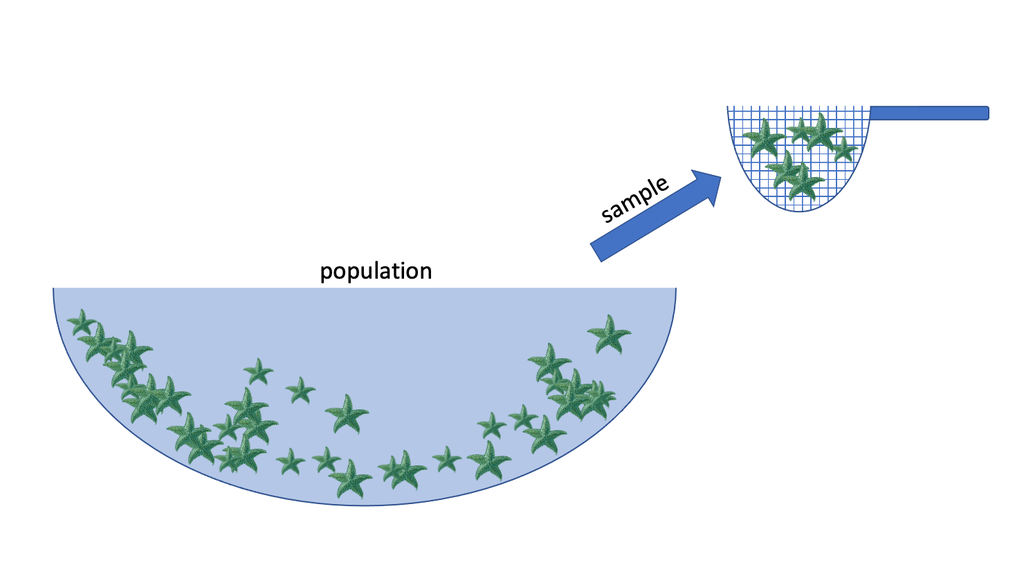

## What is statistical inference?

Statistical inference is the process of using a *sample* to make conclusions about a wider *population* the sample came from.

**Why?:** It's often expensive or not possible to measure the whole population.

#### E.g.: we want to know the average width of a species of sea star

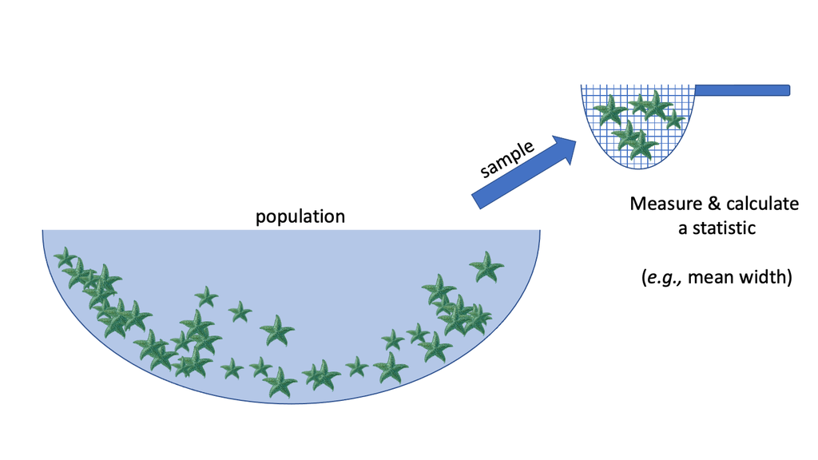

## What is statistical inference?

Statistical inference is the process of using a *sample* to make conclusions about a wider *population* the sample came from.

**Why?:** It's often expensive or not possible to measure the whole population.

#### E.g.: we want to know the average width of a species of sea star

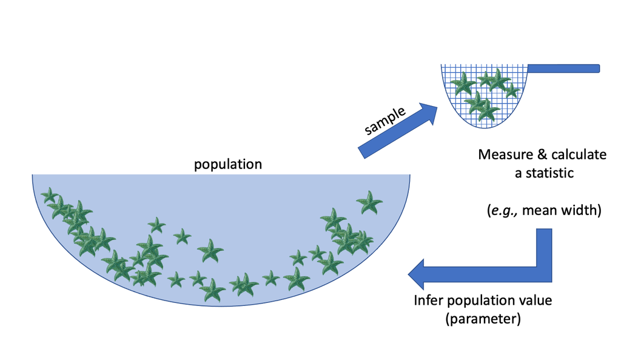

## Inference in the wild: opinion polling

Based on the results of a recent Reuters poll, we estimate that 47.2% of Americans think that firearms should have strong regulations or restrictions when thinking about gun ownership rights and gun laws.

source: http://polling.reuters.com/#!response/PV20/type/smallest/dates/20180505-20181002/collapsed/true

## Inference in the wild: market assessment

What proportion of undergraduate students have an iphone?

[figure not shown]

## Inference in the wild: A/B testing

*(not in DSCI100 - you'll need to take a more advanced DSCI or STAT class for this!)*

Which of the 2 website designs will lead to more customer engagement (measured by click-through-rate, for example)?

[figure not shown]

## Estimation

A particular inferential problem where we try to *estimate a quantitative property* of the population

This quantitative property is called a **population parameter**

**Question:** What *proportion* (a quantitative population parameter!) of UBC undergrads have an iphone?

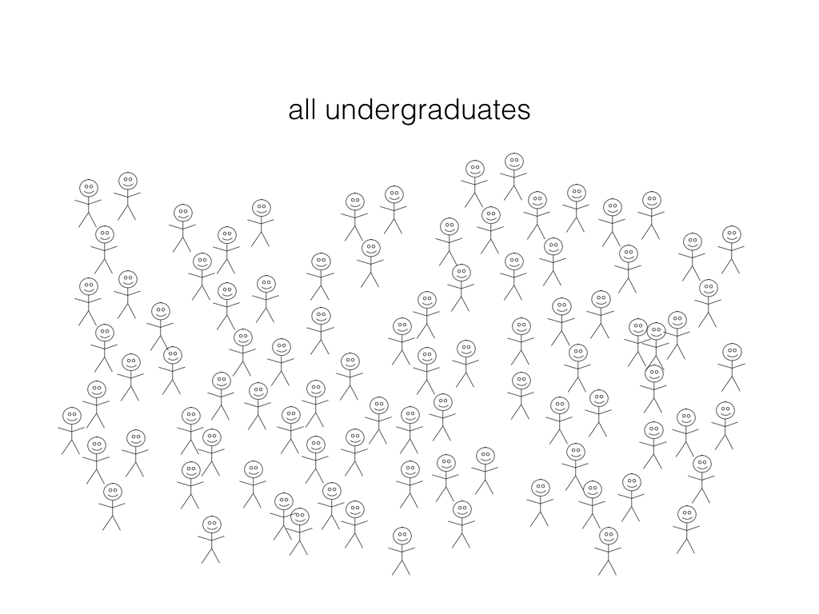

## Estimation

Step 1: randomly select a subset (a *sample*) and ask them if they have an iPhone

Step 2: calculate the proportion in our sample (a *sample estimate*) and use it as an estimate of the true population proportion.

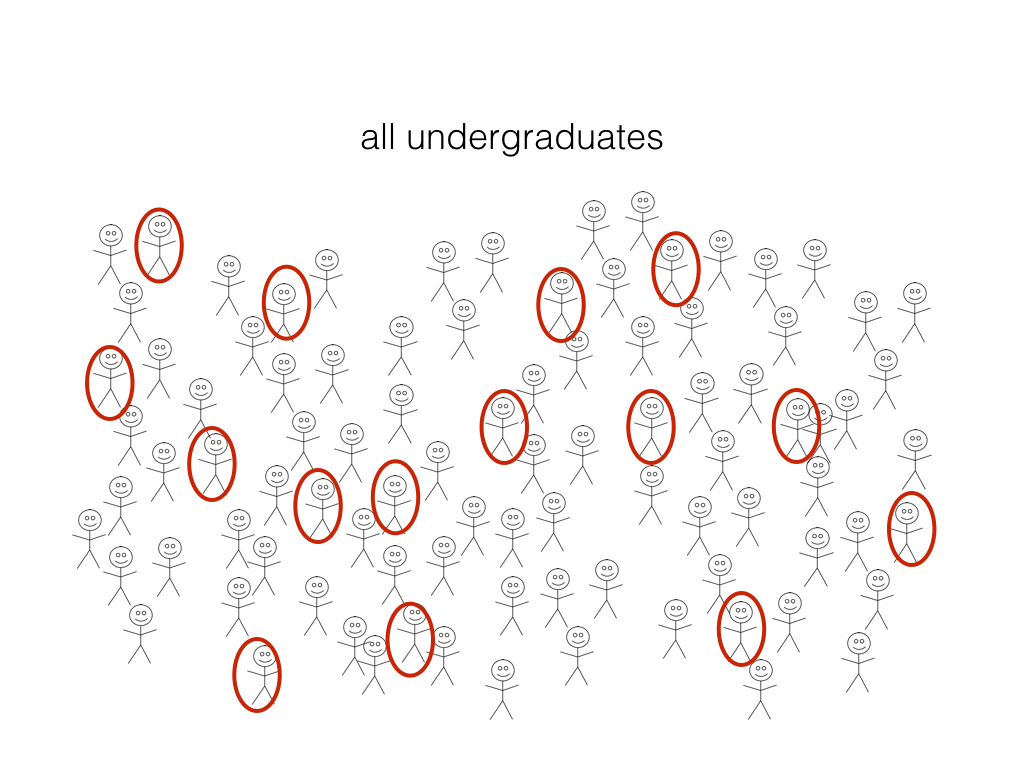